# Statistics for Environmental Science

## Week 1 - R code used in Webinar

```r
library(dplyr)
```

```r
library(stringr)
library(ggplot2)
library(tidyr)
library(DT)
```

### Data

Importing the data directly from the metoffice website. https://www.metoffice.gov.uk/pub/data/weather/uk/climate/stationdata/valleydata.txt

Whole thing needs a bit of trial and error to get the best option for formats. But using the url() function to read directly from a url along with read.table - since the data is a tab seperated plain text file - can give something workable with a few tweaks.

```r
raw<- read.table(
  url("https://www.metoffice.gov.uk/pub/data/weather/uk/climate/stationdata/valleydata.txt"),
  skip=5,
  header=TRUE,
  fill=TRUE,
  na.strings="---")
```

Check into the data

```r
datatable(raw)
```

|  | yyyy | mm | tmax | tmin | af | rain | sun |
| --- | --- | --- | --- | --- | --- | --- | --- |
| 1 | degC | degC | days | mm | hours |  |  |
| 2 | 1930 | 12 | 8.6 | 5.5 | 0 | 130.3 | 31.5 |
| 3 | 1931 | 1 | 8.0 | 4.2 | 0 | 66.2 | 63.8 |
| 4 | 1931 | 2 | 7.6 | 3.7 | 0 | 60.6 | 74.1 |
| 5 | 1931 | 3 | 8.5 | 2.4 | 6 | 32.5 | 130.3 |
| 6 | 1931 | 4 | 9.9 | 5.6 | 0 | 47.1 | 119.0 |
| 7 | 1931 | 5 | 12.9 | 8.0 | 0 | 86 | 197.1 |
| 8 | 1931 | 6 | 15.5 | 10.8 | 0 | 104.2 | 150.2 |
| 9 | 1931 | 7 | 16.5 | 12.3 | 0 | 43.5 | 150.8 |
| 10 | 1931 | 8 | 16.9 | 12.4 | 0 | 69.8 | 209.2 |

[output cut: 1074 more lines]

Now we need some more tidying up the data to make it useful.

First line is just units. Can remove from the data frame.

Because of the forced data input some rows have ‘provisional’ flags in the year column and nothing else. Lets drop those. This is a weird side effect of the autodetection of columns - this is actually in the 8th column, but since it doesnt appear til way down the bottom it gets thrown into a new row in the first column. Not actually a problem here - as we can remove this - but can be a problem othertimes.

The Provisional values have * next tp the number. So R doesnt see as numbers it sees text. We need to remove the * and convert to numbers.

Also to make plotting time series easier we can create a date column by smashing month and year together. Lazily lets just take the 1st of every month rather than worry about month-year formats.

```r
Valley<- raw %>%
  slice(-1) %>%
    filter(yyyy !="Provisional") %>%
      mutate_all(~str_remove(.,"[*]")) %>%
        mutate_all(~as.numeric(.)) %>%
          mutate(Date=as.Date(paste(yyyy,mm,"01",sep="-")))
```

```r
datatable(Valley)
```

|  | yyyy | mm | tmax | tmin | af | rain | sun | Date |
| --- | --- | --- | --- | --- | --- | --- | --- | --- |
| 1 | 1930 | 12 | 8.6 | 5.5 | 0 | 130.3 | 31.5 | 1930-12-01 |
| 2 | 1931 | 1 | 8 | 4.2 | 0 | 66.2 | 63.8 | 1931-01-01 |
| 3 | 1931 | 2 | 7.6 | 3.7 | 0 | 60.6 | 74.1 | 1931-02-01 |
| 4 | 1931 | 3 | 8.5 | 2.4 | 6 | 32.5 | 130.3 | 1931-03-01 |
| 5 | 1931 | 4 | 9.9 | 5.6 | 0 | 47.1 | 119 | 1931-04-01 |
| 6 | 1931 | 5 | 12.9 | 8 | 0 | 86 | 197.1 | 1931-05-01 |
| 7 | 1931 | 6 | 15.5 | 10.8 | 0 | 104.2 | 150.2 | 1931-06-01 |
| 8 | 1931 | 7 | 16.5 | 12.3 | 0 | 43.5 | 150.8 | 1931-07-01 |
| 9 | 1931 | 8 | 16.9 | 12.4 | 0 | 69.8 | 209.2 | 1931-08-01 |
| 10 | 1931 | 9 | 14.8 | 11.1 | 0 | 78.3 | 123.8 | 1931-09-01 |

[output cut: 1071 more lines]

Writing this out to a csv file in case i need it offline

```r
write.csv(Valley,"Valley.csv",row.names = FALSE)
```

### ‘Descriptive’ analysis

Pull out table of summary statistics for some columns. Lots of different alternatives for this. My code is probably not the most obvious way of getting there - but it works for pivotting the whole dataset into long format and then choosing what stats to present using group_by and summarise.

```r
Valley %>%
  select(tmin,tmax,af,rain,sun) %>%
  pivot_longer(cols=tmin:sun,names_to = "variable",values_to="values")%>%
  group_by(variable) %>%
  summarise(n=sum(is.na(values)==F),mean=mean(values,na.rm=T),sd=sd(values,na.rm=T),median=median(values,na.rm=T),
            min=min(values,na.rm=T),max=max(values,na.rm=T))
```

```
## # A tibble: 5 x 7
##   variable     n   mean    sd median   min   max
##   <chr>    <int>  <dbl> <dbl>  <dbl> <dbl> <dbl>
## 1 af        1081   1.59  3.27    0     0    24
## 2 rain      1080  71.2  38.9    67     1.3 254.
## 3 sun       1080 133.   67.1   128.   14.7 341.
## 4 tmax      1081  13.0   4.07   12.9   2.2  23.7
## 5 tmin      1081   7.52  3.66    7.2  -3    14.6
```

Make some basic plots. Some good/some bad

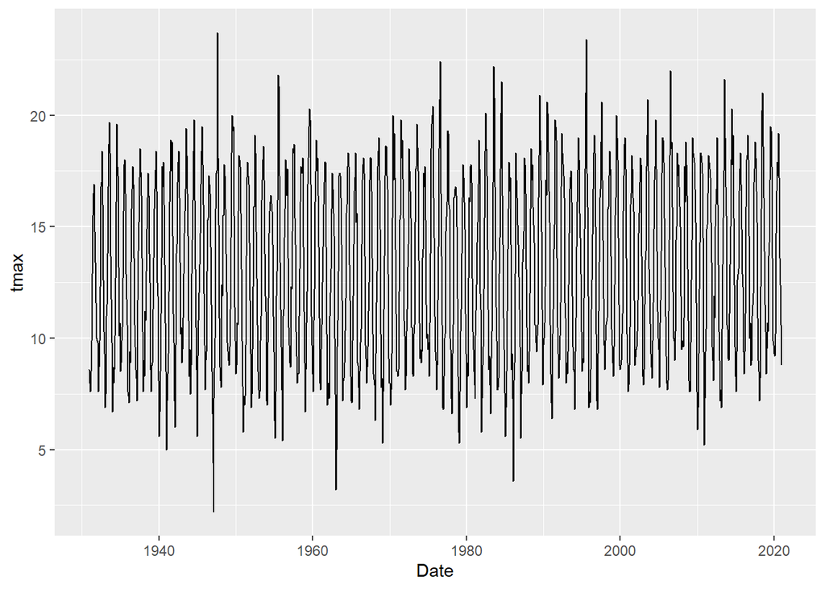

```r
ggplot(Valley,aes(y=tmax,x=Date))+
  geom_line()
```

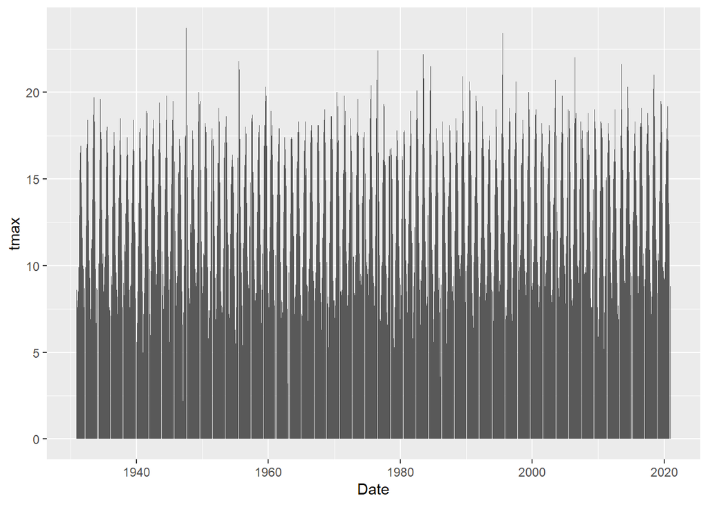

```r
ggplot(Valley,aes(y=tmax,x=Date))+
  geom_col()
```

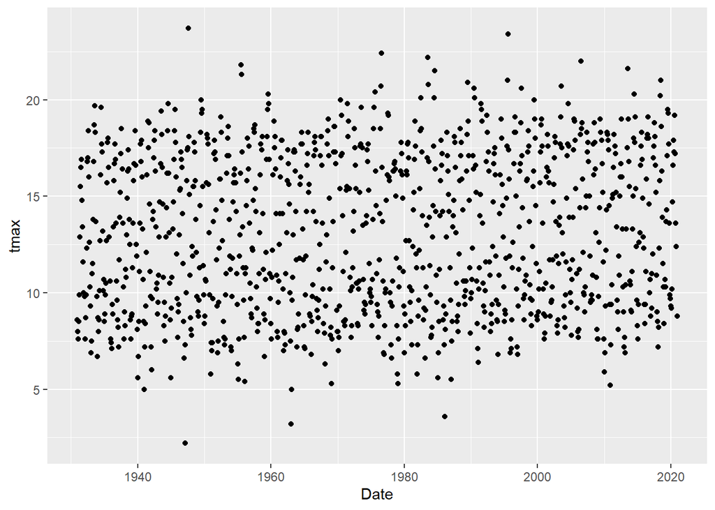

```r
ggplot(Valley,aes(y=tmax,x=Date))+
  geom_point()
```

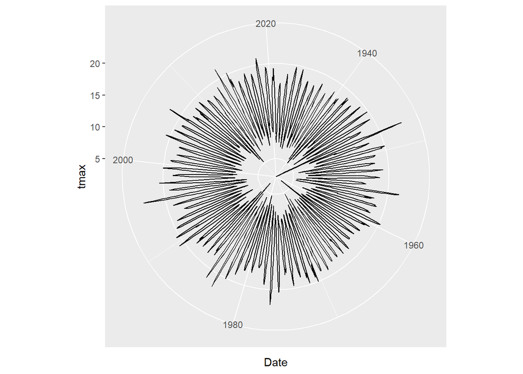

```r
ggplot(Valley,aes(y=tmax,x=Date))+
  geom_line()+
    coord_polar()
```

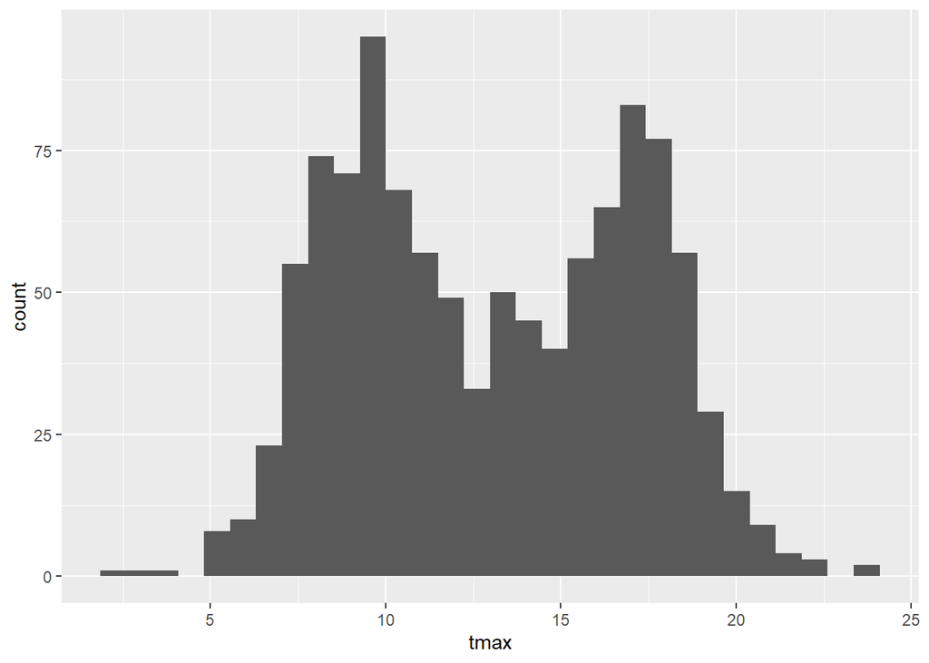

```r
ggplot(Valley,aes(x=tmax))+
  geom_histogram()
```

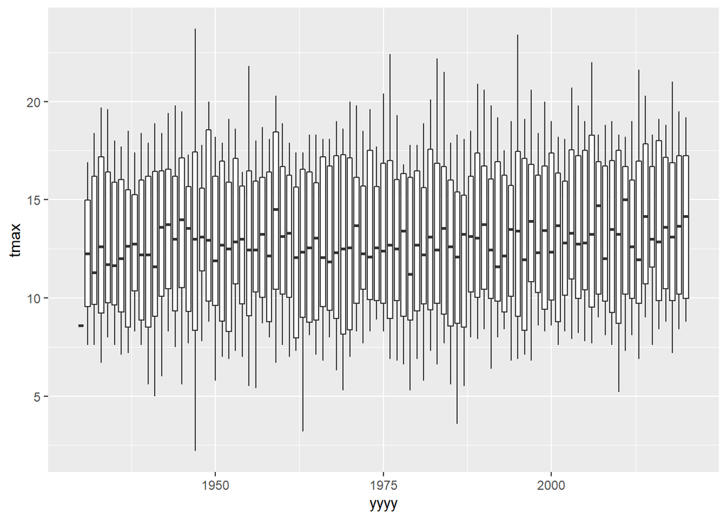

```r
ggplot(Valley,aes(y=tmax,x=yyyy,group=yyyy))+
  geom_boxplot()
```

## ‘Exploratory’ analysis

First question - is there a trend in average temperature over time?

Create average temperature variable

Obtain annual average

Plot over time

Add smoother line

Remove 1930 (since turns out we only have December 1930)

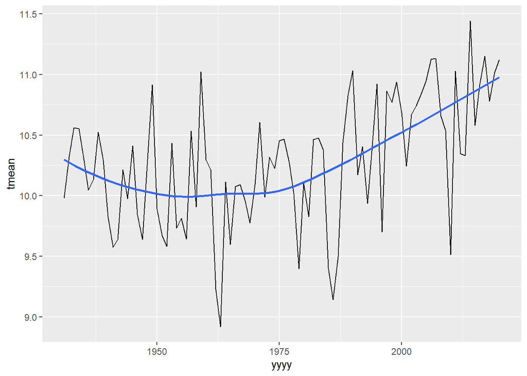

```r
Valley %>%
      mutate(tmean=(tmax+tmin)/2) %>%
        group_by(yyyy) %>%
          summarise(tmean=mean(tmean)) %>%
            filter(yyyy>1930) %>%
            ggplot(aes(y=tmean,x=yyyy))+
              geom_line()+
                geom_smooth(se=F)
```

### Seasonality

Use facets to show each month in its own panel. Compare average temperatures in each month to monthly reference average. Arbitrarily set this reference average to be years prior to 1960. Add additional line at y=0 to aid identification of trends.

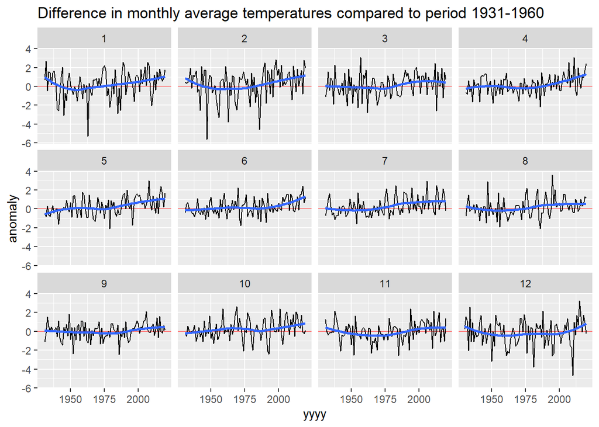

```r
Valley %>%
      mutate(tmean=(tmax+tmin)/2) %>%
        mutate(reference=ifelse(yyyy<=1960,tmean,NA)) %>%
          group_by(mm) %>%
            mutate(reference_mean=mean(reference,na.rm=T))%>%
            mutate(anomaly=tmean-reference_mean) %>%
            ggplot(aes(y=anomaly,x=yyyy))+
   geom_hline(yintercept = 0,col="red",alpha=0.5)+
              geom_line()+
                 geom_smooth(se=F)+
                  labs(col="mm")+
                    facet_wrap(~mm)+
                      ggtitle("Difference in monthly average temperatures compared to period 1931-1960")
```

### Changes in Rainfall

‘Lazy’ option:

Cut and paste temperature plot

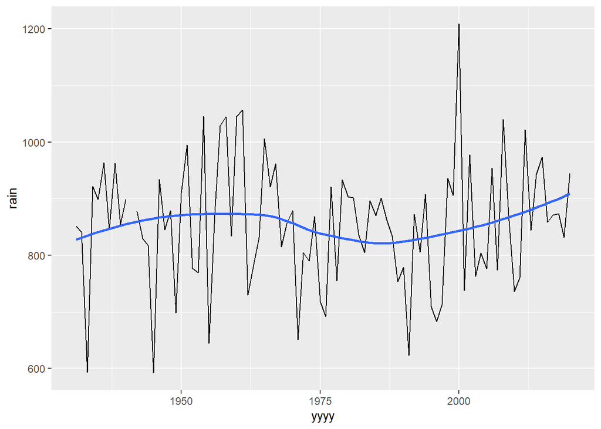

```r
Valley %>%
        group_by(yyyy) %>%
          summarise(rain=sum(rain)) %>%
            filter(yyyy>1930) %>%
            ggplot(aes(y=rain,x=yyyy))+
              geom_line()+
                geom_smooth(se=F)
```

But instead we could look at distributions:

Take first 20 years of data and compare to most recent 20 years of data. Use a density plot or a histogram

Density plot can more easily overlay - histograms you want on top of each other in panels

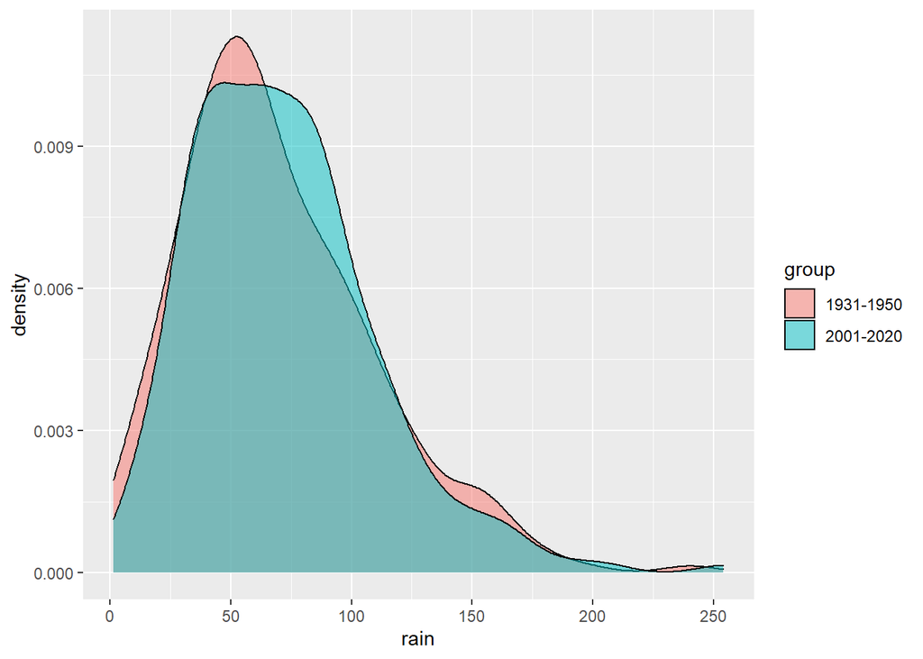

```r
Valley %>%
   filter((yyyy<=1950|yyyy>=2001)) %>%
  mutate(group=ifelse(yyyy<=1950,"1931-1950","2001-2020")) %>%
  ggplot(aes(x=rain,fill=group)) +
  geom_density(alpha=0.5)
```

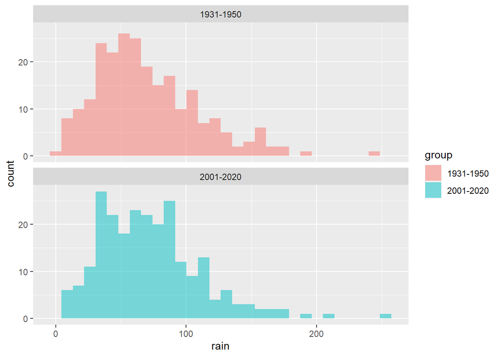

```r
Valley %>%
   filter((yyyy<=1950|yyyy>=2001)) %>%
  mutate(group=ifelse(yyyy<=1950,"1931-1950","2001-2020")) %>%
  ggplot(aes(x=rain,fill=group)) +
  geom_histogram(alpha=0.5)+
  facet_wrap(~group,ncol=1)
```

### Extremes

Or we can look at frequency of extreme months. Let’s define extreme months as being dry if less than 25mm rain; and wet if having more than 125mm rain.

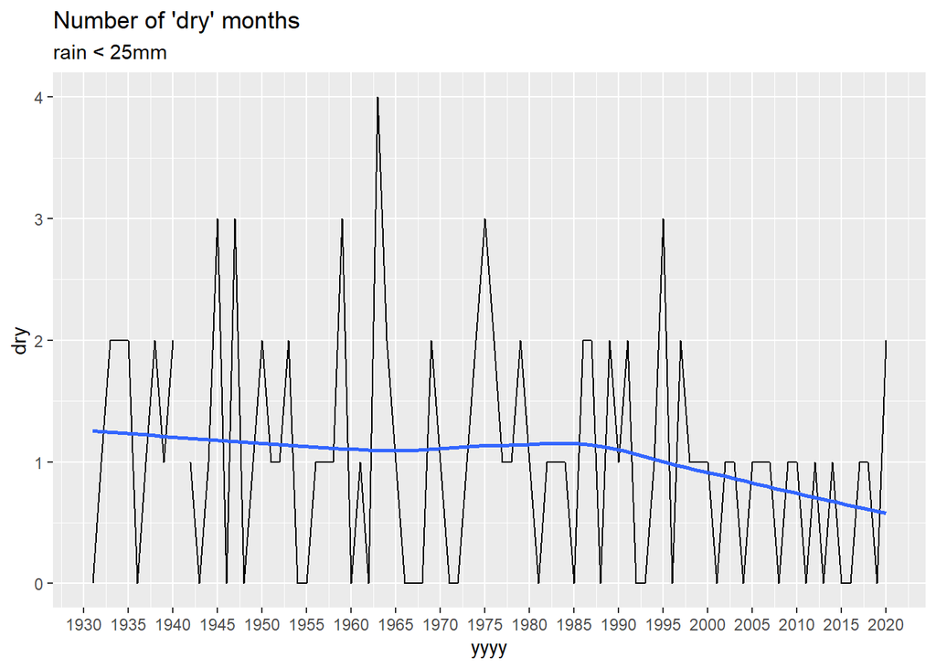

```r
Valley %>%
  group_by(yyyy) %>%
    summarise(dry=sum(rain<25)) %>%
  filter(yyyy>1930) %>%
ggplot(aes(y=dry,x=yyyy))+
  geom_line()+
    scale_x_continuous(breaks=seq(1930,2020,by=5))+
      geom_smooth(se=FALSE)+
  ggtitle("Number of 'dry' months",subtitle = "rain < 25mm")
```

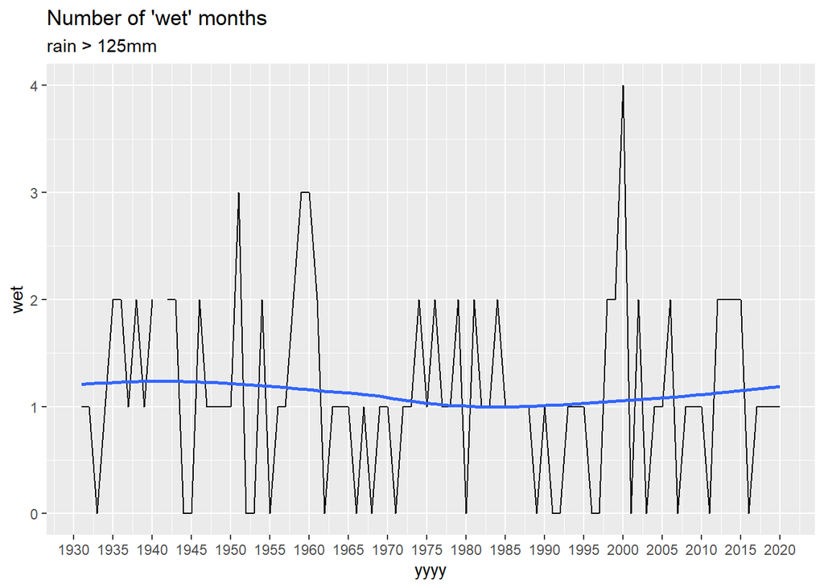

```r
Valley %>%
  group_by(yyyy) %>%
    summarise(wet=sum(rain>125)) %>%
  filter(yyyy>1930) %>%
ggplot(aes(y=wet,x=yyyy))+
  geom_line()+
    scale_x_continuous(breaks=seq(1930,2020,by=5))+
      geom_smooth(se=FALSE)+
  ggtitle("Number of 'wet' months",subtitle = "rain > 125mm")
```